# Tarea 3 Pablo Soria

Vamos a cargar los datos primero

```r
mydata <- read.csv(file="file.csv")
library(corrplot)
```

Esta base de datos tiene el registro de 395 estudiantes de matemáticas junto con datos relevantes como sexo, edad, datos demográficos familiares etc.

vamos a seleccionar ciertas variables para realizar el ejercicio de regresión, las variables que dejaremos son:

sex: Sexo  
age: Edad Pstatus: Padres divorciados  
Medu: Grado escolar de la madre  
Fedu: Grado escolar del padre  
studytime: Tiempo semanal de estudio  
paid: clases extra escolares pagadas  
Internet: Acceso a internet en casa ( binario)  
goout: Salir con amigos en escala del 1 al 5  
Dalc: consumir alcohol durante días laborales  
Walc: consumir alcohol durante los fines de semana G1: Calificación en el año 1  
G2: Calificación en el año 2 G3: Calificación en el año 3 usaremos esta variable como respuesta

Paso 1: vamos a crear una nuevo arreglo con las variables que queremos usar:

```r
myvars = c("G3","G2","G1","sex","age","Pstatus","Medu","Fedu","studytime","paid","internet","goout","Dalc","Walc")
mydata2 <- mydata[myvars]
head(mydata2)
```

```
##   G3 G2 G1 sex age Pstatus Medu Fedu studytime paid internet goout Dalc
## 1  6  6  5   F  18       A    4    4         2   no       no     4    1
## 2  6  5  5   F  17       T    1    1         2   no      yes     3    1
## 3 10  8  7   F  15       T    1    1         2  yes      yes     2    2
## 4 15 14 15   F  15       T    4    2         3  yes      yes     2    1
## 5 10 10  6   F  16       T    3    3         2  yes       no     2    1
## 6 15 15 15   M  16       T    4    3         2  yes      yes     2    1
##   Walc
## 1    1
## 2    1
## 3    3
## 4    1
## 5    2
## 6    2
```

Esto nos deja con una tabla con 9 variables numérica, 4 categoricas y la variable respuesta G3:

```r
#cambiamos las variables categoricas por 0 y 1´s
mydata2$sex <- as.integer(mydata2$sex == "M")
mydata2$Pstatus <- as.integer(mydata2$Pstatus == "A")
mydata2$paid <- as.integer(mydata2$paid == "yes")
mydata2$internet <- as.integer(mydata2$internet == "yes")
head(mydata2)
```

```
##   G3 G2 G1 sex age Pstatus Medu Fedu studytime paid internet goout Dalc
## 1  6  6  5   0  18       1    4    4         2    0        0     4    1
## 2  6  5  5   0  17       0    1    1         2    0        1     3    1
## 3 10  8  7   0  15       0    1    1         2    1        1     2    2
## 4 15 14 15   0  15       0    4    2         3    1        1     2    1
## 5 10 10  6   0  16       0    3    3         2    1        0     2    1
## 6 15 15 15   1  16       0    4    3         2    1        1     2    1
##   Walc
## 1    1
## 2    1
## 3    3
## 4    1
## 5    2
## 6    2
```

vamos a ver que nos da un primer modelo sin manipular los datos

```r
model1 <- lm(formula = G3 ~ G2 + G1 + sex + age + Pstatus + Medu + Fedu + studytime + paid + goout +Dalc + Walc,mydata2)
summary(model1)
```

```
##
## Call:
## lm(formula = G3 ~ G2 + G1 + sex + age + Pstatus + Medu + Fedu +
##     studytime + paid + goout + Dalc + Walc, data = mydata2)
##
## Residuals:
##     Min      1Q  Median      3Q     Max
## -9.1504 -0.4054  0.3190  0.9986  3.6049
##
## Coefficients:
##             Estimate Std. Error t value Pr(>|t|)
## (Intercept)  0.54661    1.44964   0.377   0.7063
## G2           0.95545    0.05116  18.674   <2e-16 ***
## G1           0.18902    0.05791   3.264   0.0012 **
## sex          0.05069    0.21800   0.233   0.8162
## age         -0.14987    0.08005  -1.872   0.0620 .
## Pstatus      0.33269    0.32359   1.028   0.3045
## Medu         0.13344    0.11860   1.125   0.2612
## Fedu        -0.13944    0.11613  -1.201   0.2306
## studytime   -0.14977    0.12824  -1.168   0.2436
## paid         0.14371    0.20604   0.698   0.4859
## goout        0.02580    0.09884   0.261   0.7942
## Dalc        -0.12031    0.14599  -0.824   0.4104
## Walc         0.14642    0.10908   1.342   0.1803
## ---
## Signif. codes:  0 '***' 0.001 '**' 0.01 '*' 0.05 '.' 0.1 ' ' 1
##
## Residual standard error: 1.934 on 382 degrees of freedom
## Multiple R-squared:  0.8273, Adjusted R-squared:  0.8219
## F-statistic: 152.5 on 12 and 382 DF,  p-value: < 2.2e-16
```

Vemos una grafica de correlación de los pares

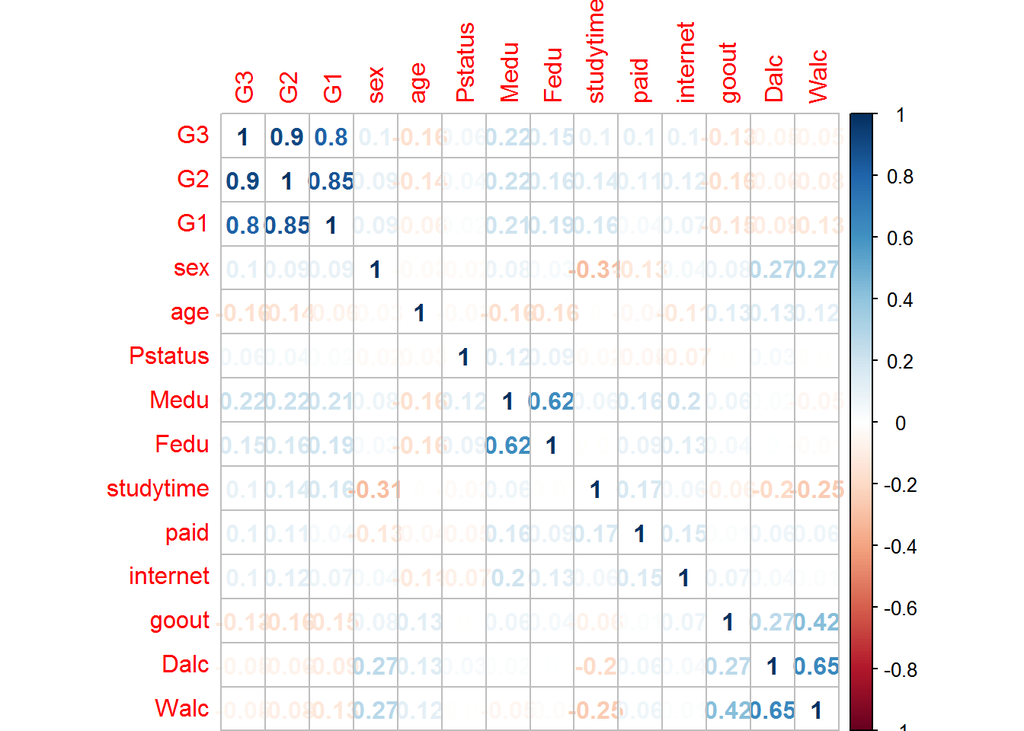

```r
corrdata <- cor(mydata2[1:14])
corrplot(corrdata, method = "number")
```

A priori con estos dos resultados encontramos lo siguiente:

1. Nuestra R2 es bastante alta, con un valor de .82, sin embargo cuando vemos la tabla de los p-value que para cada término comprueba la hipótesis nula de que el coeficiente asociada a esa variable sea cero es decir irrelevante para la regresión, este es un primer criterio para eliminar datos que no necesitamos,

2)También nos encontramos con el resultado ovbio de que la calificación en años anteriores G1 y G2 esta fuertemente relacionada con la calificación del año 3, esto es aun más evidente cuando vemos la gráfica de correlaciones a pares. Esto sugiere que existe multicolinealidad en el modelo de regresión entre G# y G" y G1

Esto nos lleva a la conclusión de que el performance final de los estudiantes se ve afectado ampliamente por el performance pasado lo cual no debería de ser una gran sorpresa

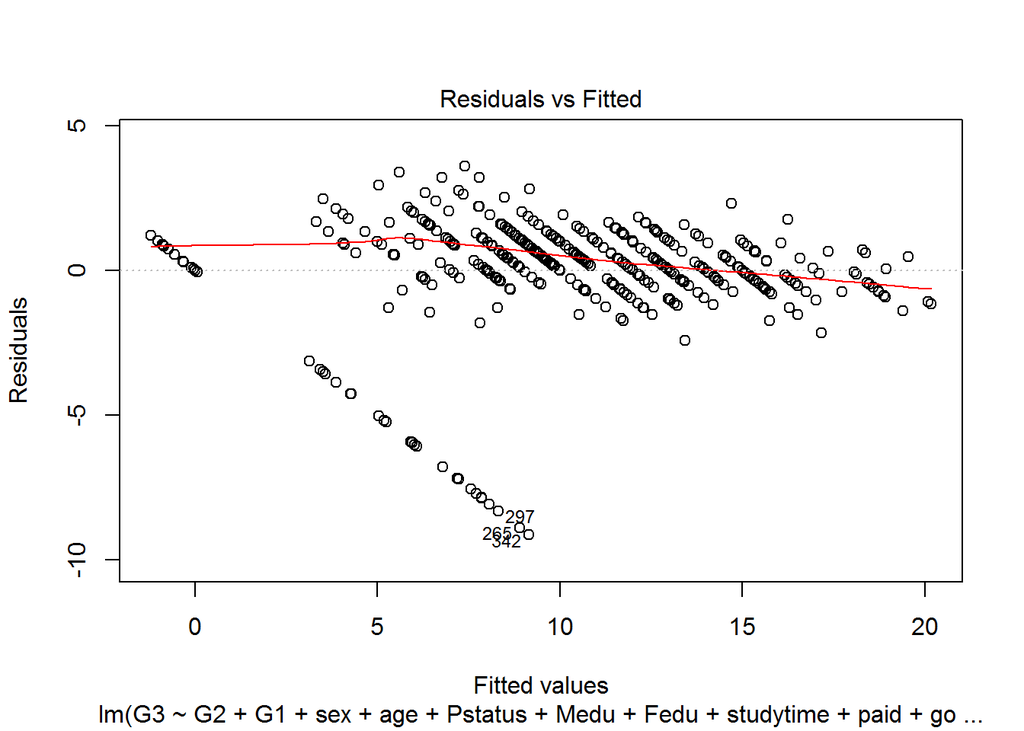

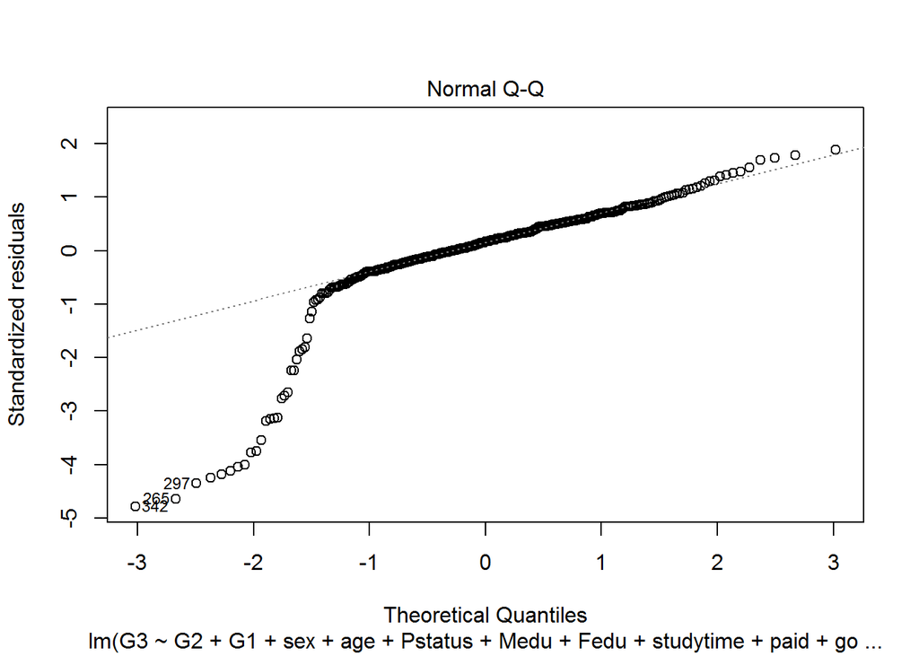

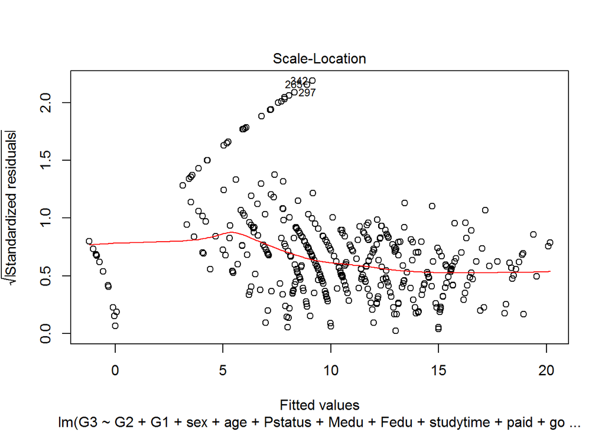

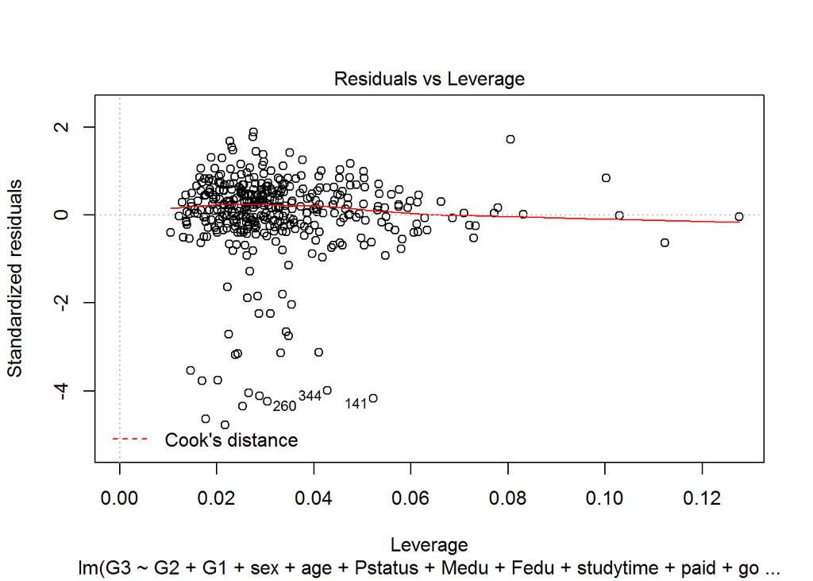

```r
plot(model1)
```

Intentemos un nuevo modelo que elimina las variables colineales evidentes,

```r
model2 <- lm(formula = G3 ~  sex + age + Pstatus + Medu + Fedu + studytime + paid + goout +Dalc + Walc,mydata2)
summary(model2)
```

```
##
## Call:
## lm(formula = G3 ~ sex + age + Pstatus + Medu + Fedu + studytime +
##     paid + goout + Dalc + Walc, data = mydata2)
##
## Residuals:
##      Min       1Q   Median       3Q      Max
## -14.0102  -1.9470   0.5506   2.7899   9.1949
##
## Coefficients:
##             Estimate Std. Error t value Pr(>|t|)
## (Intercept)  13.9928     3.1852   4.393 1.45e-05 ***
## sex           1.3338     0.4869   2.740  0.00644 **
## age          -0.3665     0.1788  -2.050  0.04103 *
## Pstatus       0.6626     0.7312   0.906  0.36539
## Medu          0.6658     0.2666   2.497  0.01293 *
## Fedu          0.1222     0.2608   0.469  0.63968
## studytime     0.6134     0.2859   2.146  0.03253 *
## paid          0.6863     0.4626   1.484  0.13871
## goout        -0.5800     0.2209  -2.625  0.00900 **
## Dalc         -0.3308     0.3300  -1.002  0.31687
## Walc          0.1891     0.2463   0.768  0.44312
## ---
## Signif. codes:  0 '***' 0.001 '**' 0.01 '*' 0.05 '.' 0.1 ' ' 1
##
## Residual standard error: 4.375 on 384 degrees of freedom
## Multiple R-squared:  0.1112, Adjusted R-squared:  0.08802
## F-statistic: 4.803 on 10 and 384 DF,  p-value: 1.612e-06
```

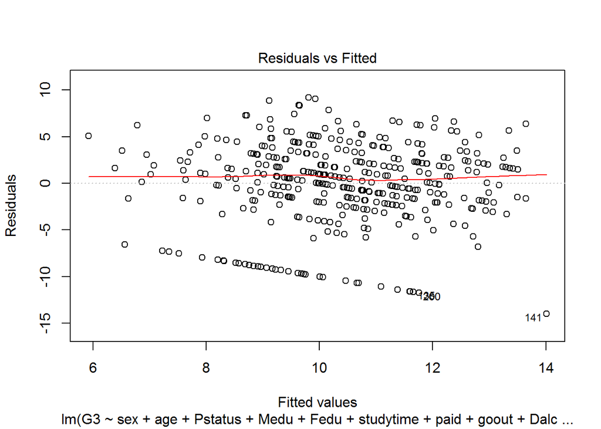

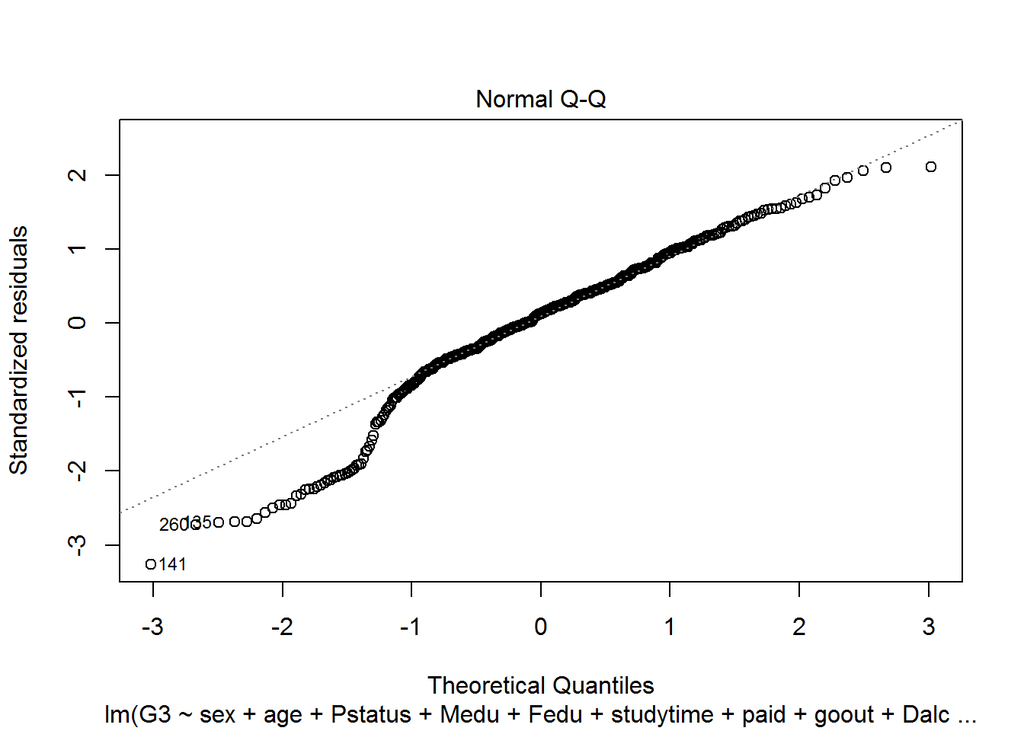

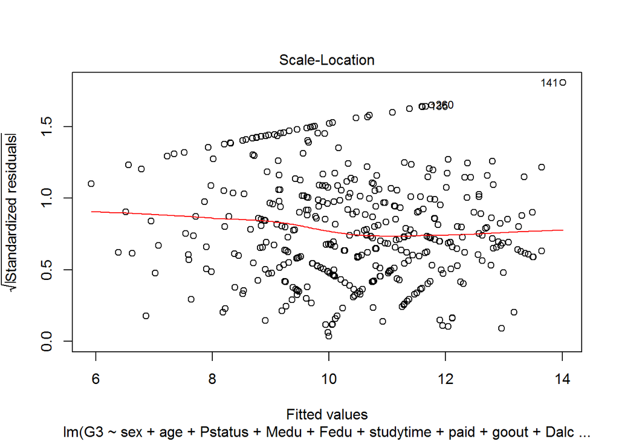

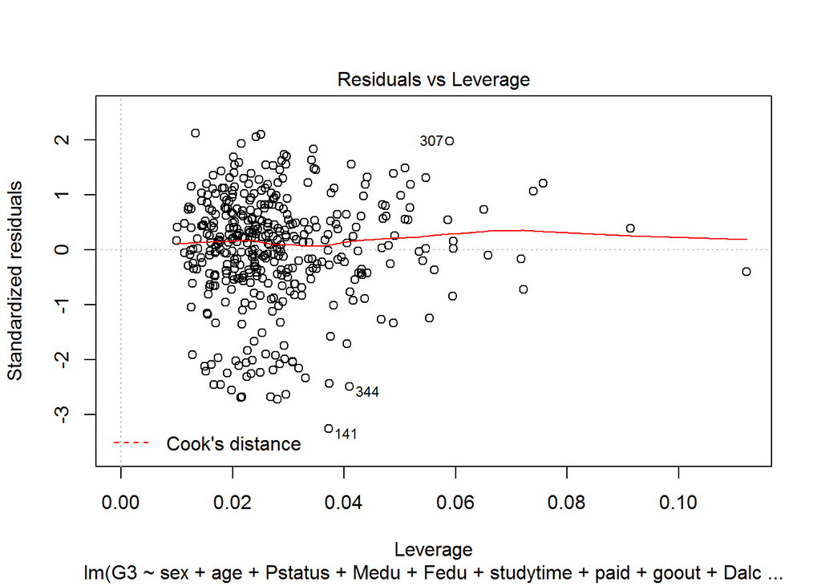

```r
plot(model2)
```

Crearemos un último modelo sencillo para hacver la estimación por máxima verosimilitu más simple:

```r
model3 <- lm(formula = G3 ~  G1 + G2,mydata2)
summary(model3)
```

```
##
## Call:
## lm(formula = G3 ~ G1 + G2, data = mydata2)
##
## Residuals:
##     Min      1Q  Median      3Q     Max
## -9.5713 -0.3888  0.2885  0.9725  3.7089
##
## Coefficients:
##             Estimate Std. Error t value Pr(>|t|)
## (Intercept) -1.83001    0.33531  -5.458 8.57e-08 ***
## G1           0.15327    0.05618   2.728  0.00665 **
## G2           0.98687    0.04957  19.909  < 2e-16 ***
## ---
## Signif. codes:  0 '***' 0.001 '**' 0.01 '*' 0.05 '.' 0.1 ' ' 1
##
## Residual standard error: 1.937 on 392 degrees of freedom
## Multiple R-squared:  0.8222, Adjusted R-squared:  0.8213
## F-statistic: 906.1 on 2 and 392 DF,  p-value: < 2.2e-16
```

Los angulaos de ambos modelos son:

```r
#Model1
ang <- acos(sqrt(0.8273))
ang*180/pi
```

```
## [1] 24.55534
```

```r
#Model2
ang <- acos(sqrt(0.1112))
ang*180/pi
```

```
## [1] 70.52068
```

```r
#Model3
ang <- acos(sqrt(0.8222))
ang*180/pi
```

```
## [1] 24.93965
```

```r
library(bbmle)
library(stats4)
y <- mydata2$G3
x1 <- mydata2$G1
x2 <- mydata2$G2
#Creamos la función de verosimilitud

likel <- function(beta0,beta1,beta2,mu,sigma){
  R <- y - x1*beta1 - x2*beta2 - beta0 #calcula los residuales
  R <- dnorm(R, mu,sigma, log = TRUE)
  -sum(R)
}

#Usaremos la librería bbmle para poder hacer el método:

fit <- mle2(likel, start = list(beta0 = -1.8, beta1 = .15,beta2 =.98, mu = 0, sigma=.8))
#Los coeficientes son
fit
```

```
##
## Call:
## mle2(minuslogl = likel, start = list(beta0 = -1.8, beta1 = 0.15,
##     beta2 = 0.98, mu = 0, sigma = 0.8))
##
## Coefficients:
##       beta0       beta1       beta2          mu       sigma
## -1.81354055  0.15262351  0.98730612 -0.01354055  1.93033059
##
## Log-likelihood: -820.12
```

```r
#Los ocmparamos contra los coeficientes originales:
model3$coefficients
```

```
## (Intercept)          G1          G2
##  -1.8300121   0.1532686   0.9868668
```

```r
#sacamos también el valor de el error estándar de los residuales
summary(model3)
```

```
##
## Call:
## lm(formula = G3 ~ G1 + G2, data = mydata2)
##
## Residuals:
##     Min      1Q  Median      3Q     Max
## -9.5713 -0.3888  0.2885  0.9725  3.7089
##
## Coefficients:
##             Estimate Std. Error t value Pr(>|t|)
## (Intercept) -1.83001    0.33531  -5.458 8.57e-08 ***
## G1           0.15327    0.05618   2.728  0.00665 **
## G2           0.98687    0.04957  19.909  < 2e-16 ***
## ---
## Signif. codes:  0 '***' 0.001 '**' 0.01 '*' 0.05 '.' 0.1 ' ' 1
##
## Residual standard error: 1.937 on 392 degrees of freedom
## Multiple R-squared:  0.8222, Adjusted R-squared:  0.8213
## F-statistic: 906.1 on 2 and 392 DF,  p-value: < 2.2e-16
```

Y vemos afortunadamente que son similares jajajaja